```python
# import the library
import numpy as np
import pandas as pd
import warnings
warnings.filterwarnings("ignore")
```

```python
# Read the Csv
haberman = pd.read_csv("haberman.csv")
```

# High Level Stastics

```python
# Number of Points And Features
print(haberman.shape)   # 306 rows and 4 feature in our haberman dataset
```

```
(306, 4)
```

```python
print(haberman.columns)
```

```
Index(['age', 'year', 'nodes', 'status'], dtype='object')
```

```python
'''
independent Variable --- age,year,nodes
dependent Variable/target variable --- status
'''
```

```
'\nindependent Variable --- age,year,nodes\ndependent Variable/target variable --- status\n'
```

```python
# number of class in target variable
#datapoint per class
print(haberman['status'].value_counts())
'''
Refrence Kaggle ---
1 = the patient survived 5 years or longer
2 = the patient died within 5 year
'''
# Two class we have in our Target Variable
```

```
1    225
2     81
Name: status, dtype: int64
```

```
'\nRefrence Kaggle ---\n1 = the patient survived 5 years or longer\n2 = the patient died within 5 year\n'
```

```python
#datapoint per class
'''
225 people surrvied after breast surgery more than five yaer means Suceesful
81 people died after surgery in five year means unsceesfull
225 people status is 1
81 people status is 2
looks like imbalanced dataset
'''
```

```
'\n225 people surrvied after breast surgery more than five yaer means Suceesful \n81 people died after surgery in five year means unsceesfull \n225 people status is 1\n81 people status is 2\nlooks like imbalanced dataset\n'
```

```python
print(haberman.head())
```

```
   age  year  nodes  status
0   30    64      1       1
1   30    62      3       1
2   30    65      0       1
3   31    59      2       1
4   31    65      4       1
```

## DATA INFORMATION ---- we have 306 Patient Informtaion.225 People survived after breast surgery more than five yaer means Suceesful.And Rest of The 81 People died before 5 Year.And Final Point is Our Dataset is Not A Balanced DataSet.

# Objective --- If a person has undergone the surgery,we have to tell that person is survived or not in 5 year based on some Features.

# Univariate Analysis -- PDF, CDF, Boxplot, Voilin plots (Which Feature is More Important)

# Histogram,CDF,PDF

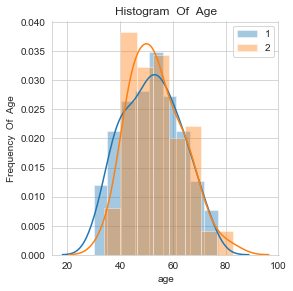

```python
# Histograms
import seaborn as sns
import matplotlib.pyplot as plt
sns.FacetGrid(haberman,hue='status',height=4).map(sns.distplot,'age')
plt.title('Histogram  Of  Age')
plt.ylabel('Frequency  Of  Age')
plt.legend()
plt.show()
```

### Conclusion -- Age is Not Important Feature.Age Frequency is Distribued Simmilarly Between Status-1 And Status-2.And Pdf is overlapping.

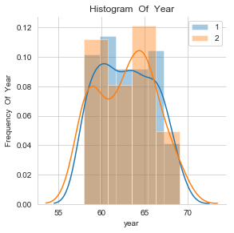

```python
sns.FacetGrid(haberman,hue='status',height=4).map(sns.distplot,'year')
plt.title('Histogram  Of  Year')
plt.ylabel('Frequency  Of  Year')
plt.legend()
plt.show()
```

### Conclusion -- Year is Not Important Feature.Year Frequency is Distribued Simmilarly Between Status-1 And Status-2.And Pdf is overlapping.

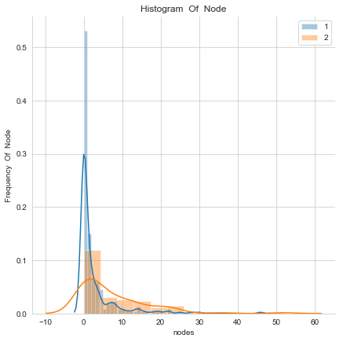

```python
sns.FacetGrid(haberman,hue='status',height=6).map(sns.distplot,'nodes')
plt.title('Histogram  Of  Node')
plt.ylabel('Frequency  Of  Node')
plt.legend()
plt.show()
```

### Conclusion -- Node is A Important Feature Here.If Node node values is less then higher chance of Patient Surrival But Node Value is high then less chance of Patient Surrival.

```python
# i will Do more reserch on nodes Features
```

```python
nodes_1 = haberman.loc[haberman['status']==1]
nodes_2 = haberman.loc[haberman['status']==2]
```

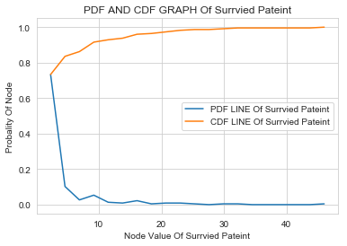

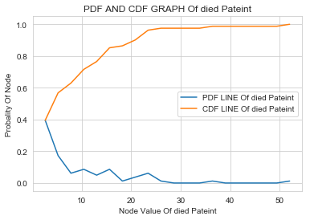

```python
count,n_bins = np.histogram(nodes_1['nodes'],bins=20,density=True)
pdf = count/sum(count)
cdf = np.cumsum(pdf)
plt.plot(n_bins[1:],pdf,label='PDF LINE Of Surrvied Pateint')
plt.plot(n_bins[1:],cdf,label='CDF LINE Of Surrvied Pateint')
plt.title('PDF AND CDF GRAPH Of Surrvied Pateint')
plt.xlabel('Node Value Of Surrvied Pateint')
plt.ylabel('Probality Of Node')
plt.legend()
plt.show()
count,n_bins = np.histogram(nodes_2['nodes'],bins=20,density=True)
pdf = count/sum(count)
cdf = np.cumsum(pdf)
plt.plot(n_bins[1:],pdf,label='PDF LINE Of died Pateint')
plt.plot(n_bins[1:],cdf,label='CDF LINE Of died Pateint')
plt.title('PDF AND CDF GRAPH Of died Pateint')
plt.xlabel('Node Value Of died Pateint')
plt.ylabel('Probality Of Node')
plt.legend()
plt.show()
```